# STT481_Hw1

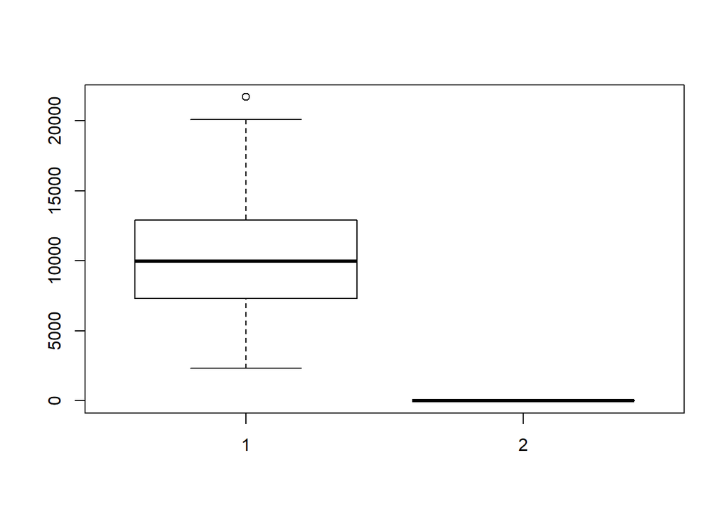

```r
#(c) iii.
boxplot(college$Outstate, college$Private)
```

4. Create a new qualitative variable, called Elite, bybinning the Top10perc variable. We are going to divide universities into two groups based on whether or not the proportion of students coming from the top 10% of their high school classes exceeds 50%.

```r
#(c) iv.

#Creates a vector of "No"'s dependant on the number of rows in the table
Elite=rep("No",nrow(college))

#Sets the values with a percent of over 50% to be a string "Yes"
Elite[college$Top10perc>50]="Yes"

#Coded "Elite" as a factory (aka category or enumerated type)
Elite=as.factor(Elite)

#Adds 'Elite' column to data set 'college'
college <- data.frame(college ,Elite)
college
```

[output not shown]

[output cut: 5391 more lines]

[output not shown]

```r
#Run summary function on cllege and ensure Eliste is contained
summary(college)
```

```
##  Private        Apps           Accept          Enroll       Top10perc
##  No :212   Min.   :   81   Min.   :   72   Min.   :  35   Min.   : 1.00
##  Yes:565   1st Qu.:  776   1st Qu.:  604   1st Qu.: 242   1st Qu.:15.00
##            Median : 1558   Median : 1110   Median : 434   Median :23.00
##            Mean   : 3002   Mean   : 2019   Mean   : 780   Mean   :27.56
##            3rd Qu.: 3624   3rd Qu.: 2424   3rd Qu.: 902   3rd Qu.:35.00
##            Max.   :48094   Max.   :26330   Max.   :6392   Max.   :96.00
##    Top25perc      F.Undergrad     P.Undergrad         Outstate
##  Min.   :  9.0   Min.   :  139   Min.   :    1.0   Min.   : 2340
##  1st Qu.: 41.0   1st Qu.:  992   1st Qu.:   95.0   1st Qu.: 7320
##  Median : 54.0   Median : 1707   Median :  353.0   Median : 9990
##  Mean   : 55.8   Mean   : 3700   Mean   :  855.3   Mean   :10441
##  3rd Qu.: 69.0   3rd Qu.: 4005   3rd Qu.:  967.0   3rd Qu.:12925
##  Max.   :100.0   Max.   :31643   Max.   :21836.0   Max.   :21700
##    Room.Board       Books           Personal         PhD
##  Min.   :1780   Min.   :  96.0   Min.   : 250   Min.   :  8.00
##  1st Qu.:3597   1st Qu.: 470.0   1st Qu.: 850   1st Qu.: 62.00
##  Median :4200   Median : 500.0   Median :1200   Median : 75.00
##  Mean   :4358   Mean   : 549.4   Mean   :1341   Mean   : 72.66
##  3rd Qu.:5050   3rd Qu.: 600.0   3rd Qu.:1700   3rd Qu.: 85.00
##  Max.   :8124   Max.   :2340.0   Max.   :6800   Max.   :103.00
##     Terminal       S.F.Ratio      perc.alumni        Expend
##  Min.   : 24.0   Min.   : 2.50   Min.   : 0.00   Min.   : 3186
##  1st Qu.: 71.0   1st Qu.:11.50   1st Qu.:13.00   1st Qu.: 6751
##  Median : 82.0   Median :13.60   Median :21.00   Median : 8377
##  Mean   : 79.7   Mean   :14.09   Mean   :22.74   Mean   : 9660
##  3rd Qu.: 92.0   3rd Qu.:16.50   3rd Qu.:31.00   3rd Qu.:10830
##  Max.   :100.0   Max.   :39.80   Max.   :64.00   Max.   :56233
##    Grad.Rate      Elite
##  Min.   : 10.00   No :699
##  1st Qu.: 53.00   Yes: 78
##  Median : 65.00
##  Mean   : 65.46
##  3rd Qu.: 78.00
##  Max.   :118.00
```

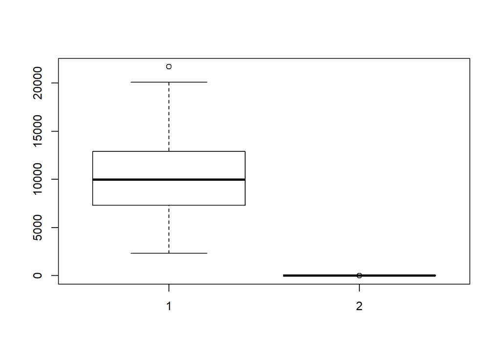

```r
#Get Count of Elite Colleges
number_of_elite <- sum(college$Elite=="Yes")

#Get Percent of Colleges Elite
percent_of_elite <- number_of_elite / (length(college$Elite))

#Boxplot of Out of State vs. Elise
boxplot(college$Outstate,college$Elite)
```

v. Use the hist() function to produce some histograms with differing numbers of bins for a few of the quantitative variables. You may find the command par(mfrow=c(2,2)) useful: it will divide the print window into four regions so that four plots can be made simultaneously. Modifying the arguments to this function will divide the screen in other ways.

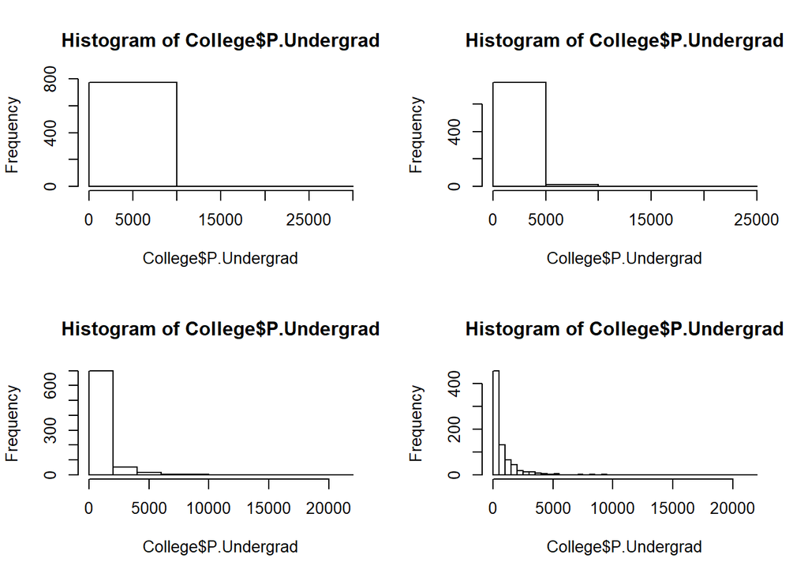

```r
#(c) v.
#Histograms for College$P.Undergrad

#Divide window into  2x2 matrix
par(mfrow=c(2,2))

#Produce 4 histograms with differing numbers of bins (designated by 'break' parameter)
hist(College$P.Undergrad, breaks= 2 )
hist(College$P.Undergrad, breaks= 6 )
hist(College$P.Undergrad, breaks= 9 )
hist(College$P.Undergrad, breaks= 45 )
```

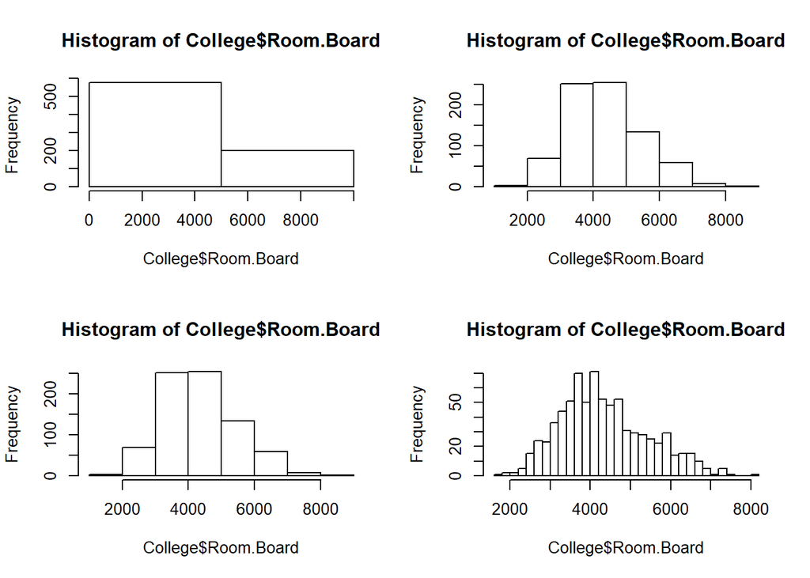

```r
#(c) v.
#Histograms for College$Room.Board

#Divide window into  2x2 matrix
par(mfrow=c(2,2))

#Produce 4 histograms with differing numbers of bins (designated by 'break' parameter)
hist(College$Room.Board, breaks= 2 )
hist(College$Room.Board, breaks= 6 )
hist(College$Room.Board, breaks= 9 )
hist(College$Room.Board, breaks= 45 )
```

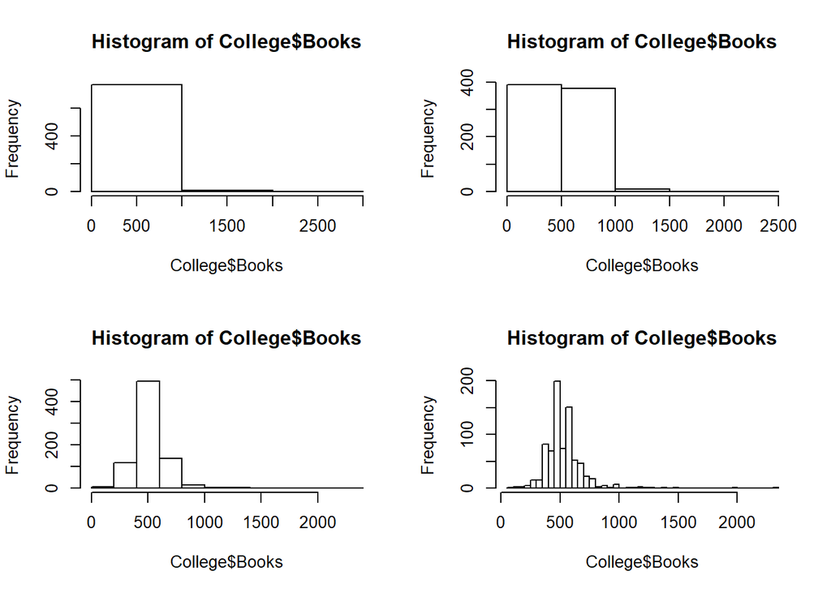

```r
#(c) v.
#Histograms for College$Books

#Divide window into  2x2 matrix
par(mfrow=c(2,2))

#Produce 4 histograms with differing numbers of bins (designated by 'break' parameter)
hist(College$Books, breaks= 2 )
hist(College$Books, breaks= 6 )
hist(College$Books, breaks= 9 )
hist(College$Books, breaks= 45 )
```

vi. Continue exploring the data, and provide a brief summary of what you discover

[figure not shown]

```r
#(c) vi.
#This did not end up being useful as there are too many variables
pairs(College)
```

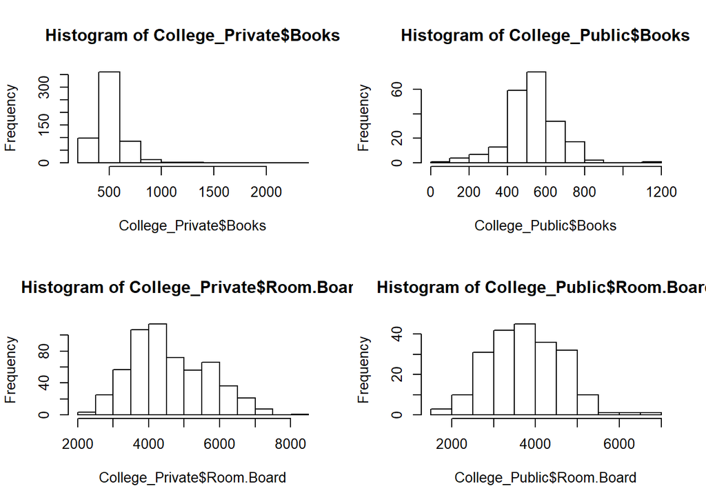

```r
College_Private = College[College$Private == 'Yes',]
College_Public = College[College$Private == 'No',]
#Create histograms to compare college cost
par(mfrow=c(2,2))
hist(College_Private$Books)
hist(College_Public$Books)

hist(College_Private$Room.Board)
hist(College_Public$Room.Board)
```

```r
#(c) vi.
avg_g_rate_priv <- mean(College_Private$Grad.Rate)
avg_g_rate_pub <- mean(College_Public$Grad.Rate)

t.test(College_Private$Grad.Rate,College_Public$Grad.Rate)
```

```
##
##  Welch Two Sample t-test
##
## data:  College_Private$Grad.Rate and College_Public$Grad.Rate
## t = 10.579, df = 431.97, p-value < 2.2e-16
## alternative hypothesis: true difference in means is not equal to 0
## 95 percent confidence interval:
##  10.54880 15.36276
## sample estimates:
## mean of x mean of y
##  68.99823  56.04245
```

I then examined the graduation rates between the two categories of insitutions and found there was a significant difference in their graduation rates.

This was interesting because I was wondering if higher costs would actually be reflected in the graduation rates.

Section 2.4: Question #9.

This exercise involves the Auto data set studied in the lab. Make sure that the missing values have been removed from the data.

```r
#9
#View data and remove columns with missing data points
#Auto

#Removes any rows with a missing data point
Auto_rm <- na.omit(Auto)
#Auto_rm
```

1. Which of the predictors are quantitative, and which are qualitative?

```r
#View all variables using summary function
summary(Auto_rm)
```

```
##       mpg          cylinders      displacement     horsepower
##  Min.   : 9.00   Min.   :3.000   Min.   : 68.0   Min.   : 46.0
##  1st Qu.:17.00   1st Qu.:4.000   1st Qu.:105.0   1st Qu.: 75.0
##  Median :22.75   Median :4.000   Median :151.0   Median : 93.5
##  Mean   :23.45   Mean   :5.472   Mean   :194.4   Mean   :104.5
##  3rd Qu.:29.00   3rd Qu.:8.000   3rd Qu.:275.8   3rd Qu.:126.0
##  Max.   :46.60   Max.   :8.000   Max.   :455.0   Max.   :230.0
##
##      weight      acceleration        year           origin
##  Min.   :1613   Min.   : 8.00   Min.   :70.00   Min.   :1.000
##  1st Qu.:2225   1st Qu.:13.78   1st Qu.:73.00   1st Qu.:1.000
##  Median :2804   Median :15.50   Median :76.00   Median :1.000
##  Mean   :2978   Mean   :15.54   Mean   :75.98   Mean   :1.577
##  3rd Qu.:3615   3rd Qu.:17.02   3rd Qu.:79.00   3rd Qu.:2.000
##  Max.   :5140   Max.   :24.80   Max.   :82.00   Max.   :3.000
##
##                  name
##  amc matador       :  5
##  ford pinto        :  5
##  toyota corolla    :  5
##  amc gremlin       :  4
##  amc hornet        :  4
##  chevrolet chevette:  4
##  (Other)           :365
```

```r
#Create a vector of all the quantitative variables
quant_vars <- c("mpg","cylinders","displacement","horsepower","weight","acceleration")

#Create a vector of all the qualitative variables
qual_vars <- c("name","year","origin",NA,NA,NA)

#Create and display columns containing quant_vars and qual_vars (quantitative variables and qualitative variables respectively)
Variable_Type <- data.frame(quant_vars,qual_vars)
Variable_Type
```

```
##     quant_vars qual_vars
## 1          mpg      name
## 2    cylinders      year
## 3 displacement    origin
## 4   horsepower      <NA>
## 5       weight      <NA>
## 6 acceleration      <NA>
```

2. What is the range of each quantitative predictor? You can answer this using the range() function.

```r
#Calculates range of all quantitative variables variables
range(Auto_rm$mpg)
```

```
## [1]  9.0 46.6
```

```r
range(Auto_rm$cylinders)
```

```
## [1] 3 8
```

```r
range(Auto_rm$displacement)
```

```
## [1]  68 455
```

```r
range(Auto_rm$horsepower)
```

```
## [1]  46 230
```

```r
range(Auto_rm$weight)
```

```
## [1] 1613 5140
```

```r
range(Auto_rm$acceleration)
```

```
## [1]  8.0 24.8
```

3. What is the mean and standard deviation of each quantitative predictor?

```r
#(c)
#Calc mean and sd of mpg
mean(Auto_rm$mpg)
```

```
## [1] 23.44592
```

```r
sd(Auto_rm$mpg)
```

```
## [1] 7.805007
```

```r
#Calc mean and sd of cylinders
mean(Auto_rm$cylinders)
```

```
## [1] 5.471939
```

```r
sd(Auto_rm$cylinders)
```

```
## [1] 1.705783
```

```r
#Calc mean and sd of displacement
mean(Auto_rm$displacement)
```

```
## [1] 194.412
```

```r
sd(Auto_rm$displacement)
```

```
## [1] 104.644
```

```r
#Calc mean and sd of horsepower
mean(Auto_rm$horsepower)
```

```
## [1] 104.4694
```

```r
sd(Auto_rm$horsepower)
```

```
## [1] 38.49116
```

```r
#Calc mean and sd of weight
mean(Auto_rm$weight)
```

```
## [1] 2977.584
```

```r
sd(Auto_rm$weight)
```

```
## [1] 849.4026
```

```r
#Calc mean and sd of acceleration
mean(Auto_rm$acceleration)
```

```
## [1] 15.54133
```

```r
sd(Auto_rm$acceleration)
```

```
## [1] 2.758864
```

4. Now remove the 10th through 85th observations. What is the range, mean, and standard deviation of each predictor in the subset of the data that remains

```r
#(d)
#Create  data set of rows 10 - 85 of 'Auto_rm'
Auto_rm2 <- Auto_rm[c(-10:-85),]
#Display new data set 'Auto_rm2'
#Auto_rm2


#Returns means of key quantitative columns
colMeans(Auto_rm2[1:6])
```

```
##          mpg    cylinders displacement   horsepower       weight
##    24.404430     5.373418   187.240506   100.721519  2935.971519
## acceleration
##    15.726899
```

```r
sapply(Auto_rm2[1:6], sd)
```

```
##          mpg    cylinders displacement   horsepower       weight
##     7.867283     1.654179    99.678367    35.708853   811.300208
## acceleration
##     2.693721
```

```r
sapply(Auto_rm2[1:6], range)
```

```
##       mpg cylinders displacement horsepower weight acceleration
## [1,] 11.0         3           68         46   1649          8.5
## [2,] 46.6         8          455        230   4997         24.8
```

5. Using the full data set, investigate the predictors graphically, using scatterplots or other tools of your choice. Create some plots highlighting the relationships among the predictors. Comment on your findings.

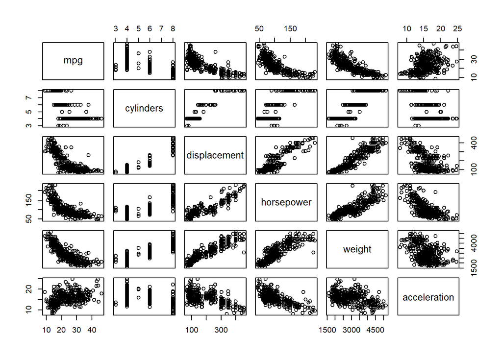

```r
pairs(Auto_rm[1:6])
```

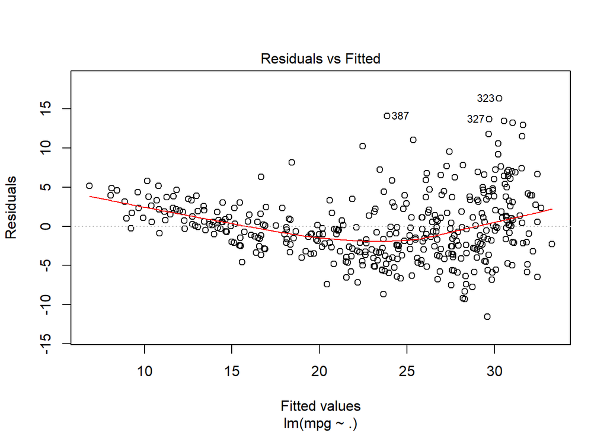

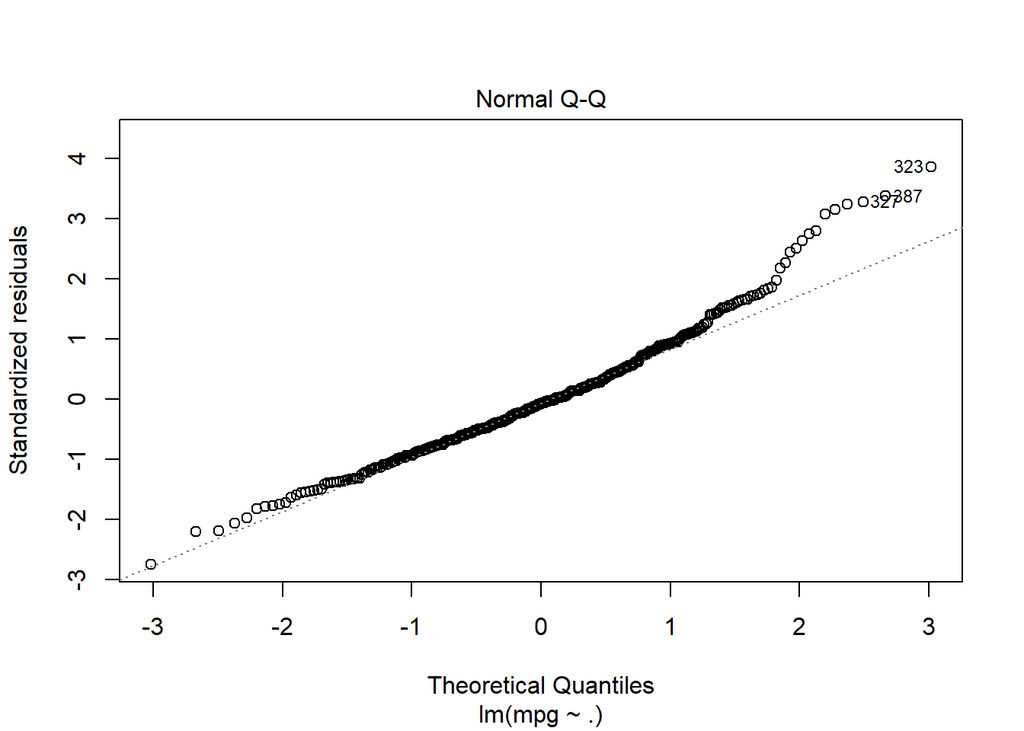

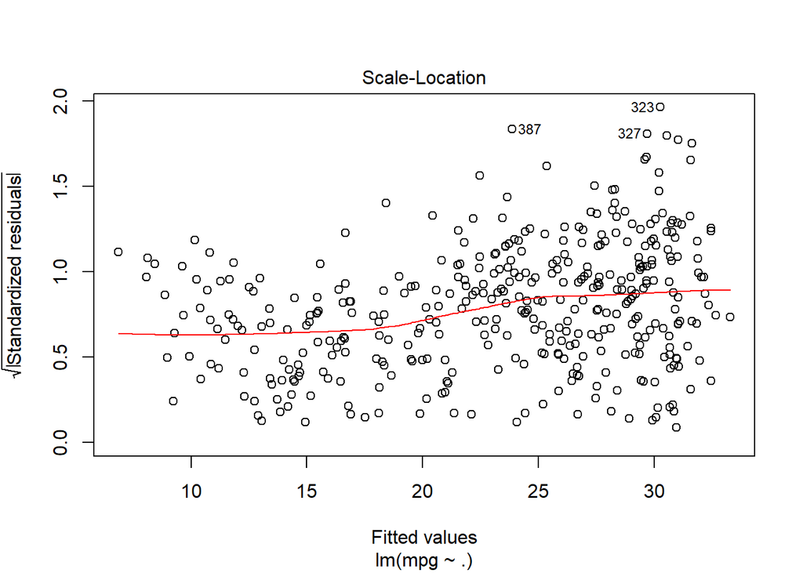

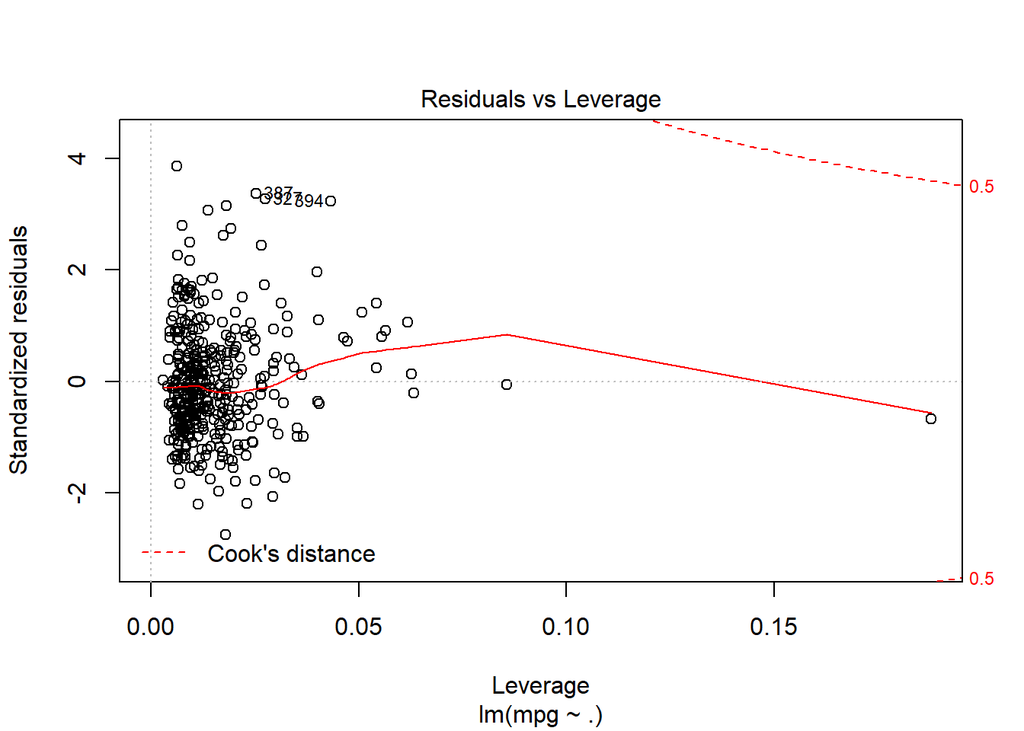

```r
plot(lm(mpg~ ., data = Auto_rm[1:6]))
```

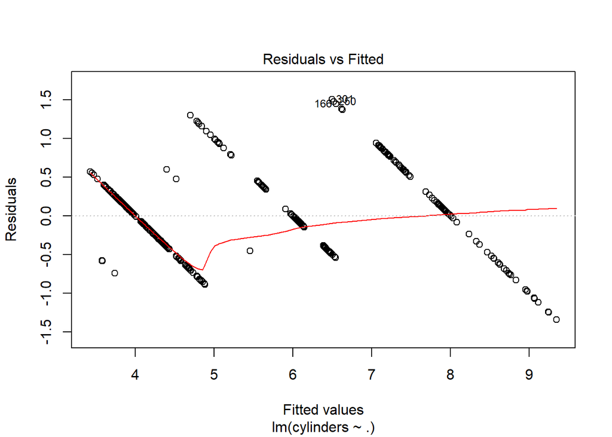

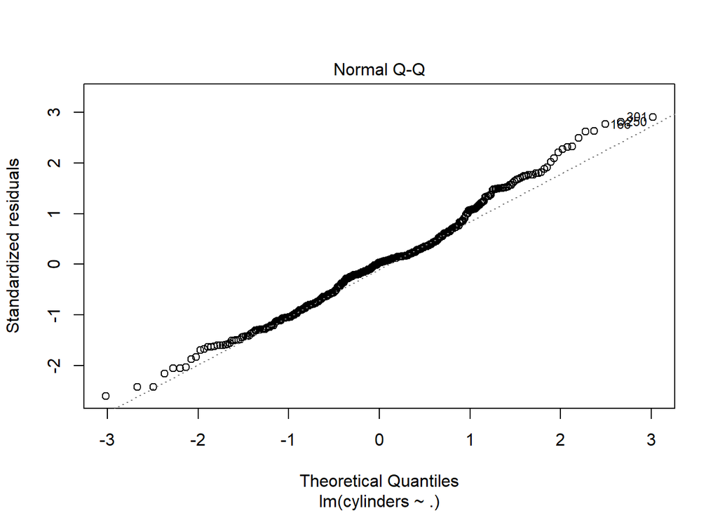

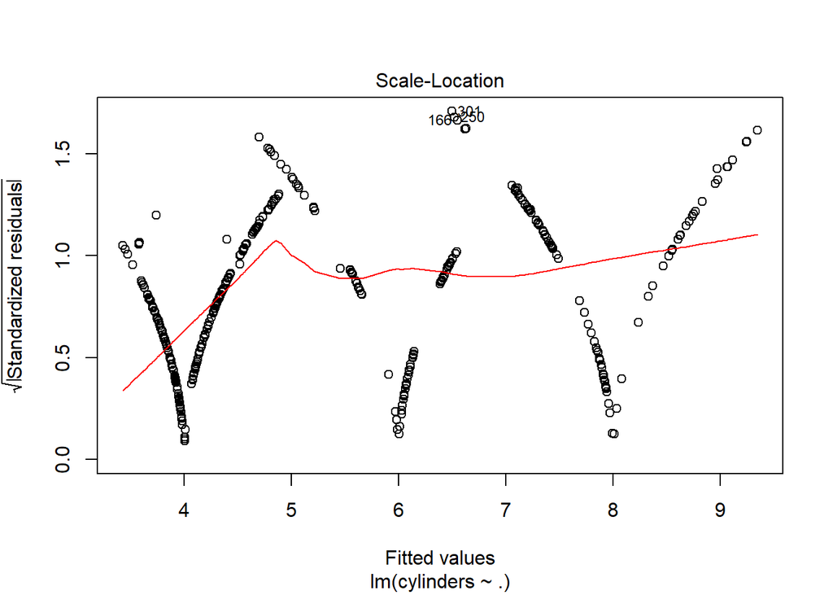

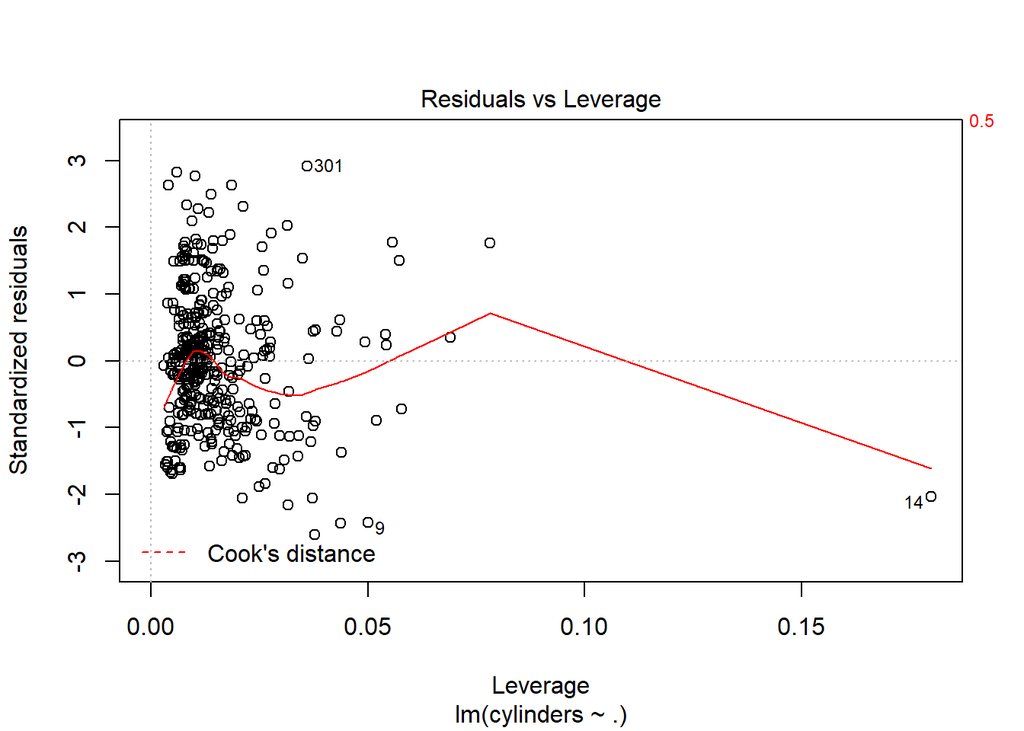

```r
plot(lm(cylinders~ ., data = Auto_rm[1:6]))
```

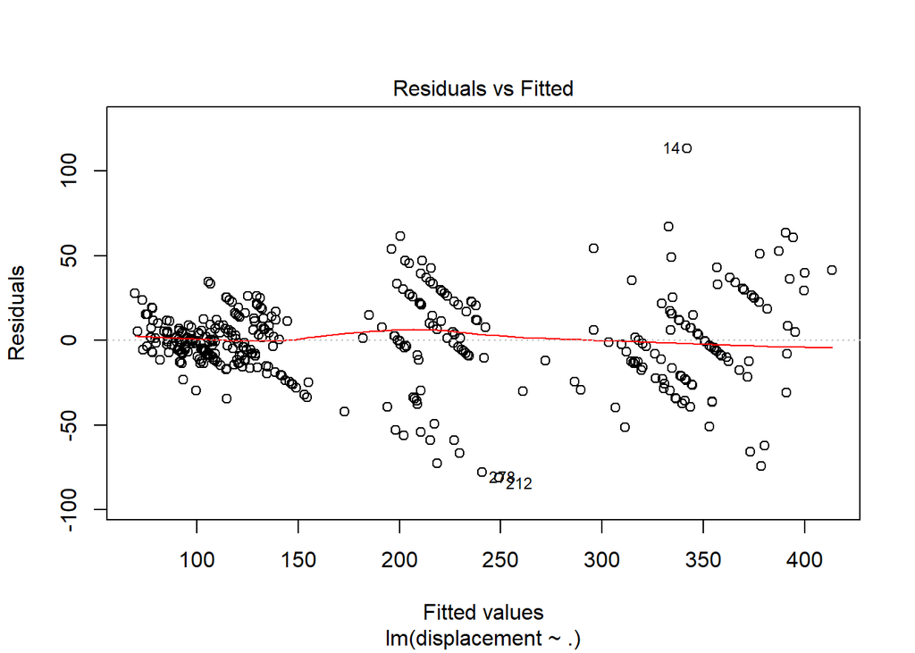

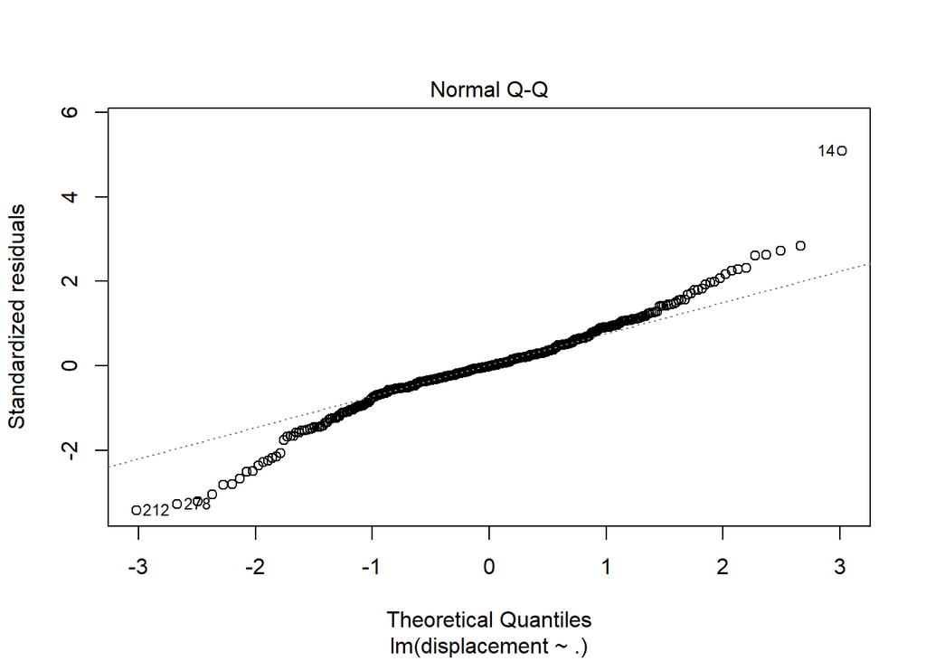

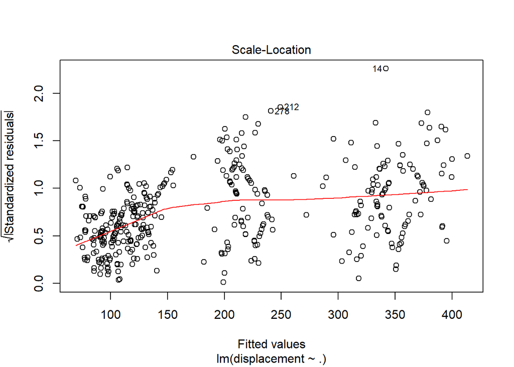

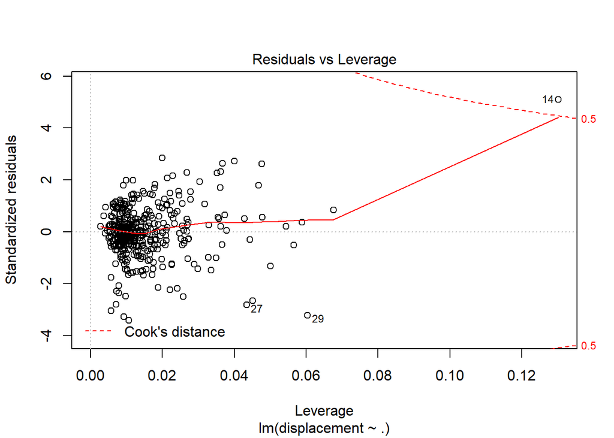

```r
plot(lm(displacement~ ., data = Auto_rm[1:6]))
```

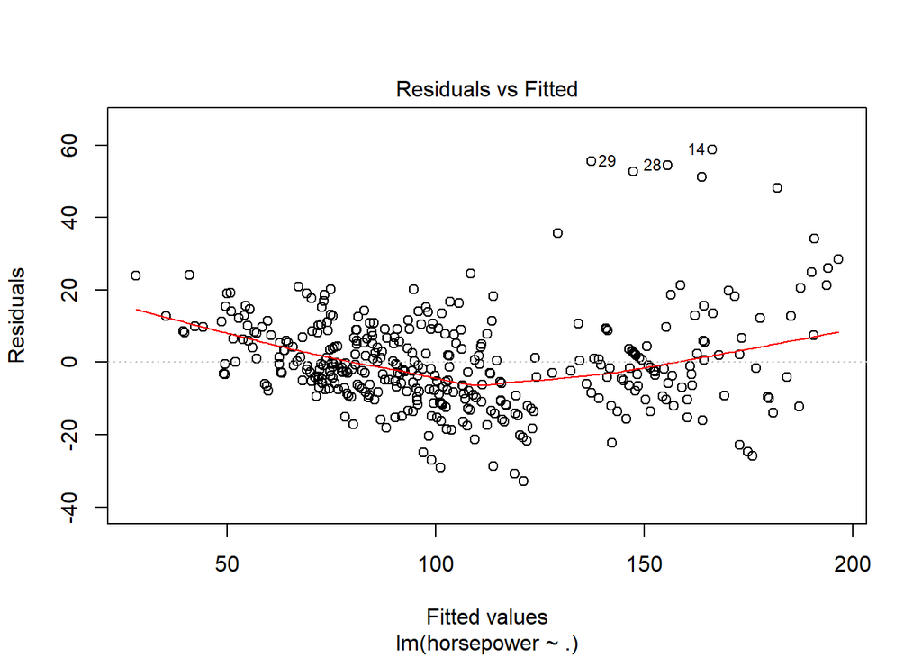

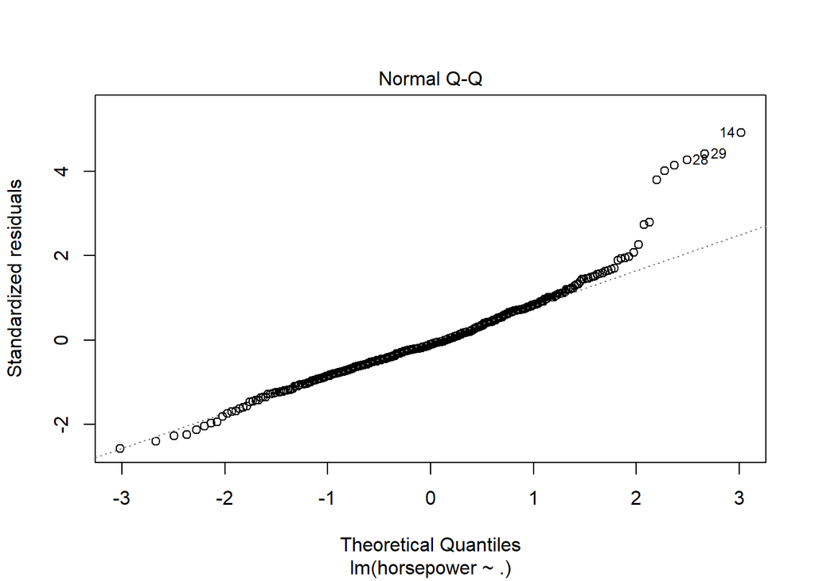

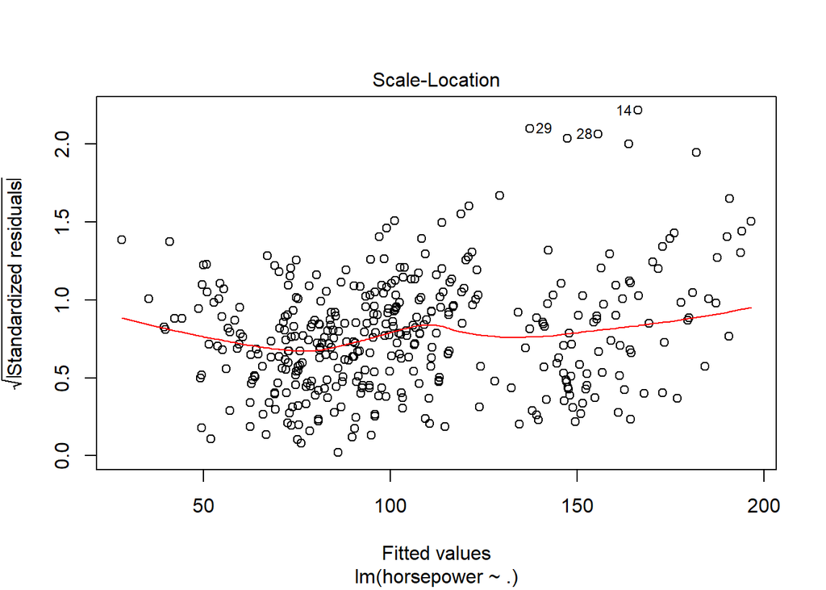

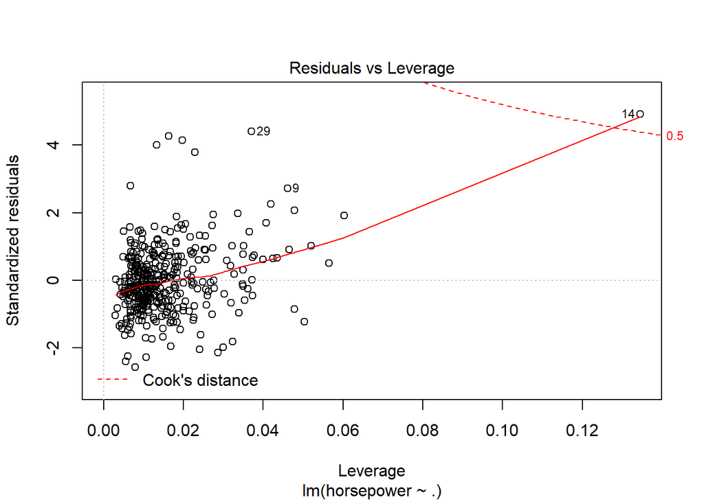

```r
plot(lm(horsepower~ ., data = Auto_rm[1:6]))
```

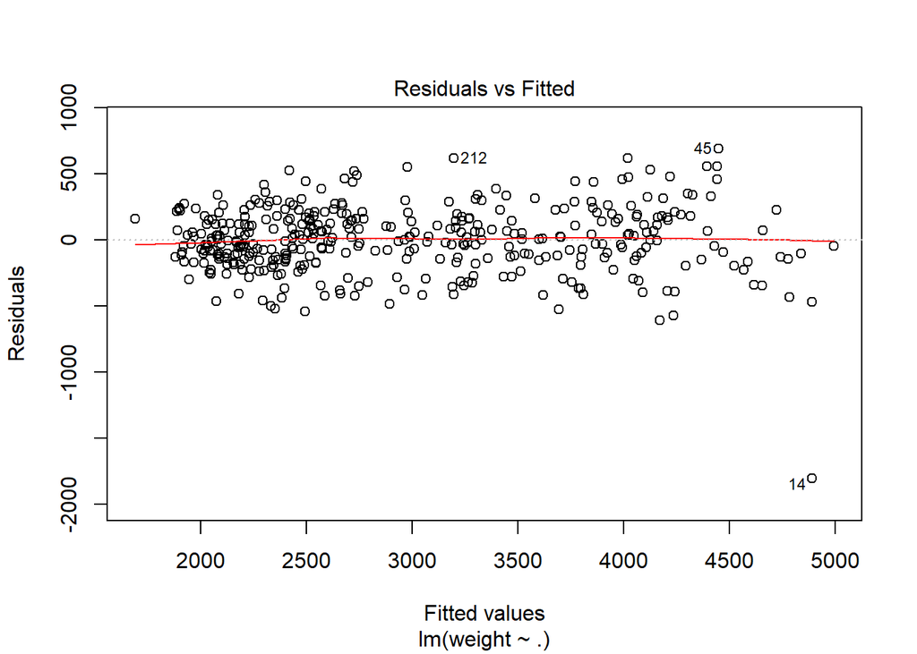

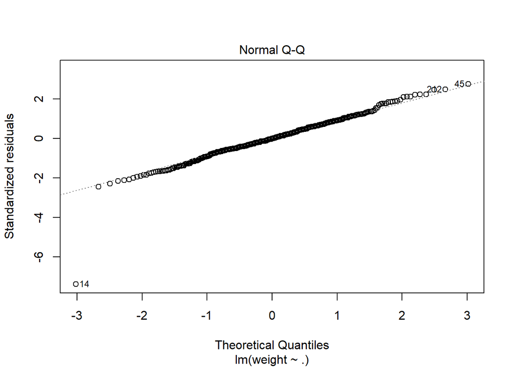

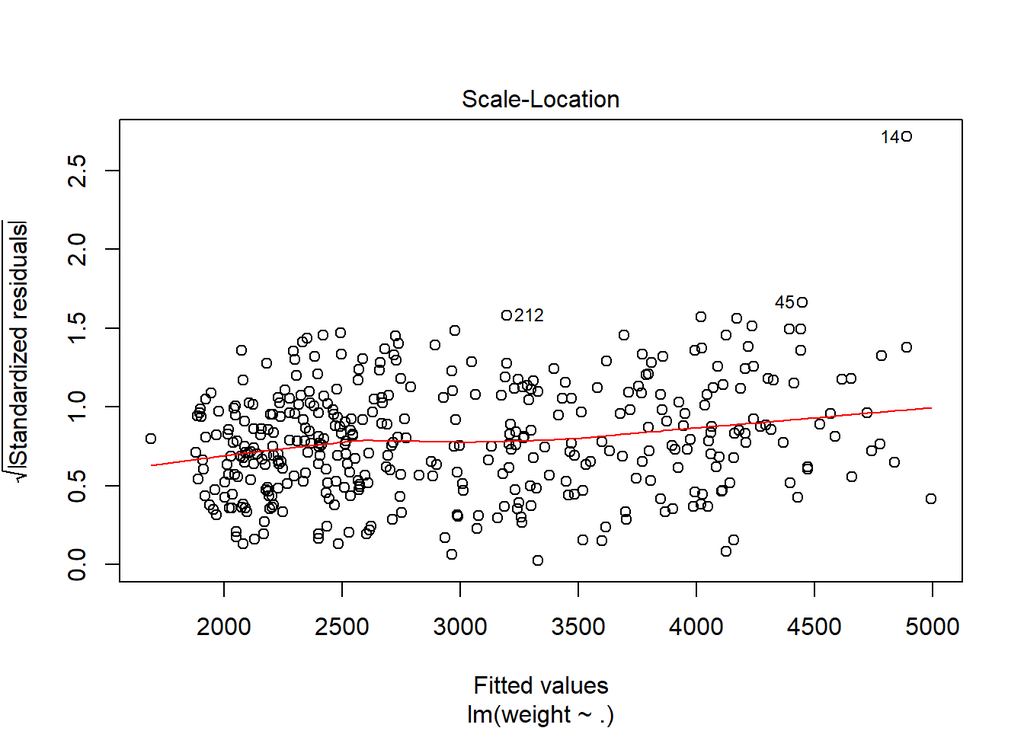

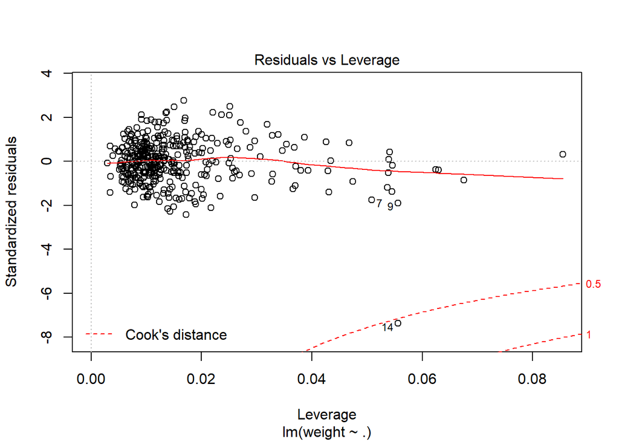

```r
plot(lm(weight~ ., data = Auto_rm[1:6]))
```